## ДОНЕЦКИЙ ГОСУДАРСТВЕННЫЙ УНИВЕРСИТЕТ

### Кафедра информационных технологий

# Сквозной анализ данных и прогнозирование стоимости автомобилей с использованием методов машинного обучения и Explainable AI

Выполнила:  
Бааджи Ю. В. Группа:  
ИВТ-5

Проверил:  
профессор кафедры компьютерных технологий,  
Аверин Г. В.

## Донецк — 2026

# Введение

В современном мире объём данных, связанных с экономическими, техническими и социальными процессами, постоянно увеличивается. В связи с этим особую актуальность приобретают методы статистического анализа данных и машинного обучения, позволяющие выявлять закономерности, строить прогнозы и принимать обоснованные решения на основе информации.

Одной из востребованных практических задач является прогнозирование стоимости автомобилей. Цена транспортного средства зависит от большого количества факторов: года выпуска, пробега, мощности двигателя, марки автомобиля, типа топлива, коробки передач и других характеристик. Анализ подобных данных позволяет не только оценивать рыночную стоимость автомобилей, но и выявлять наиболее значимые факторы, влияющие на формирование цены.

В рамках данного проекта рассматривается задача построения модели машинного обучения для прогнозирования стоимости автомобилей на основе их технических характеристик. Для решения поставленной задачи используется полный цикл анализа данных: от предварительной обработки и визуального исследования данных до построения и интерпретации модели машинного обучения.

Особое внимание уделяется применению современных инструментов анализа данных и Explainable AI (XAI). Использование методов интерпретации модели позволяет определить, какие признаки оказывают наибольшее влияние на итоговый прогноз стоимости автомобиля. Это делает модель более прозрачной и понятной для пользователя.

Также в проекте используются элементы автоматизированной генерации аналитических выводов с применением больших языковых моделей (LLM), что соответствует современным тенденциям развития интеллектуальных систем обработки данных.

Целью проекта является проведение комплексного анализа данных и построение модели прогнозирования стоимости автомобилей с использованием методов статистического анализа, машинного обучения и Explainable AI.

Для достижения поставленной цели необходимо решить следующие задачи:

- выполнить загрузку и предварительный анализ датасета;
- провести обработку пропусков и анализ структуры данных;
- выполнить разведочный анализ данных (EDA);
- исследовать взаимосвязь признаков с целевой переменной;
- подготовить данные для обучения модели;
- построить baseline-модель машинного обучения;
- оценить качество модели с использованием метрик регрессии;
- выполнить интерпретацию модели с использованием библиотеки SHAP;
- сформировать аналитические выводы по результатам исследования.

Практическая значимость проекта заключается в возможности использования разработанной модели для предварительной оценки рыночной стоимости автомобилей, а также для анализа факторов, наиболее сильно влияющих на формирование цены транспортного средства.

# 1. Загрузка и описание датасета

Для выполнения проекта используется датасет, содержащий информацию о характеристиках автомобилей и их стоимости. Набор данных включает как числовые, так и категориальные признаки, что позволяет применять методы статистического анализа и машинного обучения для решения задачи регрессии.

Целевой переменной является:

- `selling_price` — стоимость автомобиля.

В датасете представлены следующие признаки:

- марка автомобиля (`brand`);
- модель автомобиля (`model`);
- год выпуска (`year`);
- пробег (`km_driven`);
- тип топлива (`fuel`);
- тип коробки передач (`transmission`);
- тип владельца (`owner`);
- объём двигателя (`engine`);
- мощность двигателя (`max_power`);
- количество мест (`seats`).

Используемый набор данных соответствует требованиям проекта, так как содержит более 1000 наблюдений, числовые и категориальные признаки, а также чётко определённую целевую переменную.

|  | brand | model | year | km_driven | fuel | transmission | owner | engine | max_power | seats | selling_price |
| --- | --- | --- | --- | --- | --- | --- | --- | --- | --- | --- | --- |
| 0 | Volkswagen | Passat | 2008 | 199393 | Diesel | Manual | First Owner | 1571 | 122 | 7 | 616371 |
| 1 | Volkswagen | Tiguan | 2010 | 159794 | Diesel | Manual | First Owner | 1383 | 181 | 4 | 819622 |
| 2 | Kia | Cerato | 2008 | 152127 | Petrol | Automatic | First Owner | 2839 | 371 | 5 | 1746249 |
| 3 | Ford | Focus | 2013 | 188013 | Diesel | Automatic | Second Owner | 1636 | 180 | 5 | 1397828 |
| 4 | Toyota | Corolla | 2020 | 30353 | Diesel | Automatic | Third Owner | 2083 | 92 | 7 | 1646620 |

```
<class 'pandas.DataFrame'>
RangeIndex: 2500 entries, 0 to 2499
Data columns (total 11 columns):
 #   Column         Non-Null Count  Dtype
---  ------         --------------  -----
 0   brand          2500 non-null   str
 1   model          2500 non-null   str
 2   year           2500 non-null   int64
 3   km_driven      2500 non-null   int64
 4   fuel           2500 non-null   str
 5   transmission   2500 non-null   str
 6   owner          2500 non-null   str
 7   engine         2500 non-null   int64
 8   max_power      2500 non-null   int64
 9   seats          2500 non-null   int64
 10  selling_price  2500 non-null   int64
dtypes: int64(6), str(5)
memory usage: 215.0 KB
```

```
(2500, 11)
```

|  | year | km_driven | engine | max_power | seats | selling_price |
| --- | --- | --- | --- | --- | --- | --- |
| count | 2500.000000 | 2500.000000 | 2500.000000 | 2500.000000 | 2500.000000 | 2.500000e+03 |
| mean | 2015.818000 | 124296.741600 | 2523.698000 | 239.134000 | 5.355600 | 2.142320e+06 |
| std | 4.828727 | 69893.817575 | 868.097171 | 94.817742 | 1.248428 | 8.065424e+05 |
| min | 2008.000000 | 5089.000000 | 1002.000000 | 70.000000 | 4.000000 | 4.542150e+05 |
| 25% | 2012.000000 | 64309.500000 | 1777.750000 | 157.000000 | 4.000000 | 1.547923e+06 |
| 50% | 2016.000000 | 122699.500000 | 2530.500000 | 243.000000 | 5.000000 | 1.960636e+06 |
| 75% | 2020.000000 | 183443.000000 | 3297.250000 | 319.000000 | 7.000000 | 2.699389e+06 |
| max | 2024.000000 | 249923.000000 | 4000.000000 | 400.000000 | 7.000000 | 4.717354e+06 |

## Вывод

В ходе предварительного анализа датасета была исследована структура набора данных, содержащего информацию о характеристиках автомобилей и их рыночной стоимости. Анализ показал, что датасет включает достаточное количество наблюдений и признаков для решения задачи прогнозирования стоимости автомобилей с использованием методов машинного обучения.

Набор данных содержит как числовые, так и категориальные признаки, что позволяет провести комплексный анализ факторов, влияющих на стоимость транспортных средств. Среди представленных признаков имеются технические характеристики автомобилей, параметры эксплуатации, а также сведения о типе топлива и коробке передач.

Проведённый анализ структуры данных позволил определить типы переменных, оценить размерность датасета и получить основные описательные статистики. Полученные результаты свидетельствуют о том, что данные являются пригодными для дальнейшего этапа разведочного анализа (EDA) и построения модели машинного обучения.

Использование описательной статистики позволяет оценить диапазон значений признаков, выявить возможные аномалии и сформировать общее представление о распределении данных. Это является важным этапом подготовки данных перед обучением моделей машинного обучения и интерпретацией результатов прогнозирования.

# 2. Разведочный анализ данных (EDA)

Разведочный анализ данных (Exploratory Data Analysis, EDA) проводится с целью изучения структуры набора данных, выявления закономерностей, анализа распределений признаков и исследования взаимосвязей между переменными.

На данном этапе выполняется:

- анализ пропущенных значений;
- анализ распределений признаков;
- исследование корреляций;
- визуализация взаимосвязей между признаками и целевой переменной;
- выявление факторов, оказывающих влияние на стоимость автомобилей.

```
brand            0
model            0
year             0
km_driven        0
fuel             0
transmission     0
owner            0
engine           0
max_power        0
seats            0
selling_price    0
dtype: int64
```

## Анализ пропущенных значений

Проверка набора данных показала отсутствие пропущенных значений во всех признаках датасета. Это позволяет использовать данные без дополнительной обработки пропусков и упрощает дальнейший этап анализа и построения модели машинного обучения.

Отсутствие пропущенных значений положительно влияет на качество анализа данных и снижает вероятность возникновения ошибок при обучении модели.

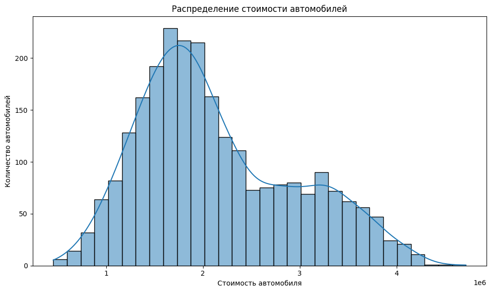

## Анализ распределения стоимости автомобилей

Анализ распределения целевой переменной показал, что большинство автомобилей находится в среднем ценовом диапазоне. При этом в датасете присутствуют автомобили с существенно более высокой стоимостью, что может быть связано с премиальными марками и улучшенными техническими характеристиками.

Распределение стоимости имеет выраженную правостороннюю асимметрию, что является типичной особенностью данных о рыночной стоимости автомобилей. Наличие более дорогих автомобилей формирует длинный правый хвост распределения.

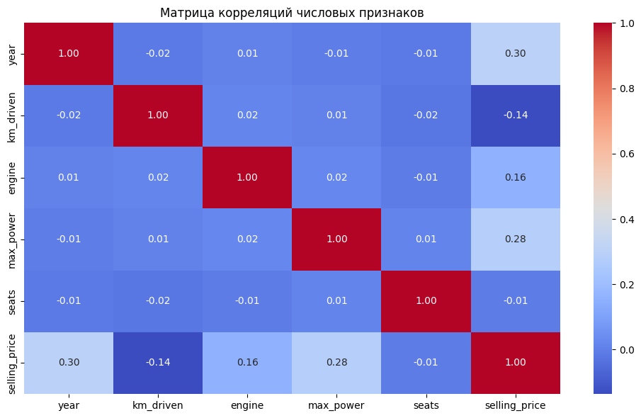

## Корреляционный анализ признаков

Корреляционный анализ позволил выявить взаимосвязи между числовыми признаками датасета и целевой переменной.

Наиболее сильное положительное влияние на стоимость автомобиля оказывают:

- год выпуска автомобиля;
- мощность двигателя;
- объём двигателя.

Отрицательная корреляция наблюдается между стоимостью автомобиля и величиной пробега. Это свидетельствует о том, что увеличение пробега, как правило, приводит к снижению рыночной стоимости транспортного средства.

Полученные результаты соответствуют реальным закономерностям автомобильного рынка и подтверждают корректность сформированного набора данных.

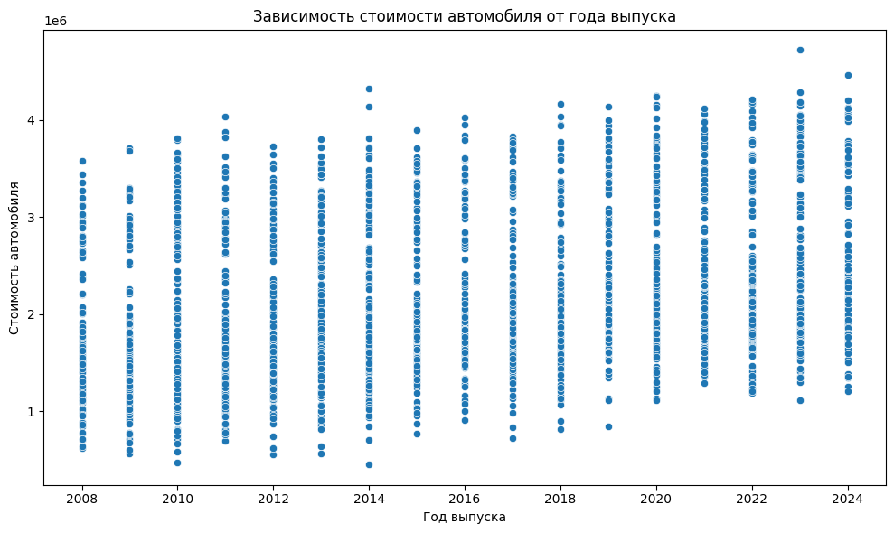

## Анализ зависимости стоимости автомобиля от года выпуска

Построенный график демонстрирует наличие положительной зависимости между годом выпуска автомобиля и его стоимостью. Более новые автомобили, как правило, имеют более высокую рыночную стоимость по сравнению со старыми транспортными средствами.

Полученная зависимость объясняется тем, что современные автомобили обладают меньшим уровнем износа, более актуальными техническими характеристиками и лучшим состоянием эксплуатации.

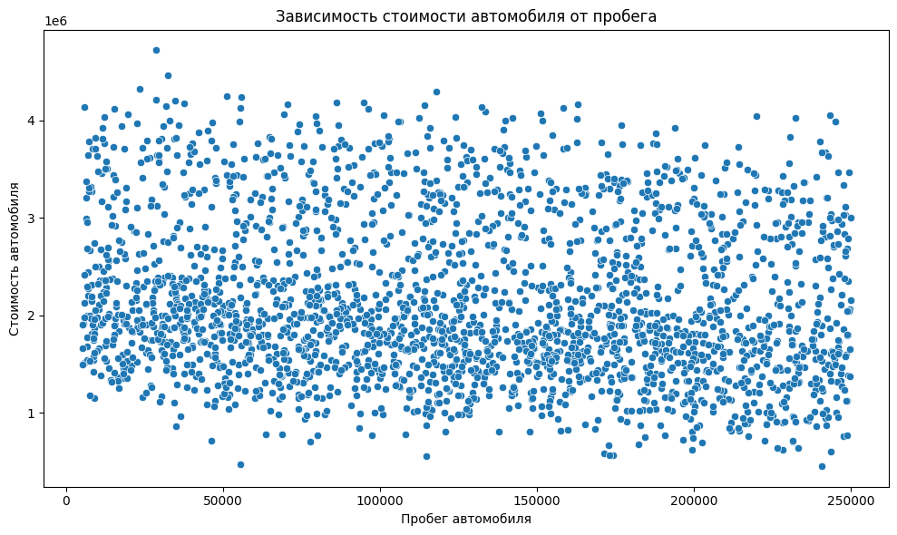

## Анализ зависимости стоимости автомобиля от пробега

Анализ графика показывает наличие отрицательной зависимости между пробегом автомобиля и его стоимостью. С увеличением пробега рыночная стоимость транспортного средства, как правило, снижается.

Полученная закономерность является ожидаемой, поскольку автомобили с большим пробегом имеют более высокий уровень эксплуатационного износа и требуют дополнительных затрат на обслуживание.

На графике также наблюдается наличие отдельных автомобилей с высокой стоимостью при значительном пробеге, что может быть связано с премиальными марками или улучшенными техническими характеристиками.

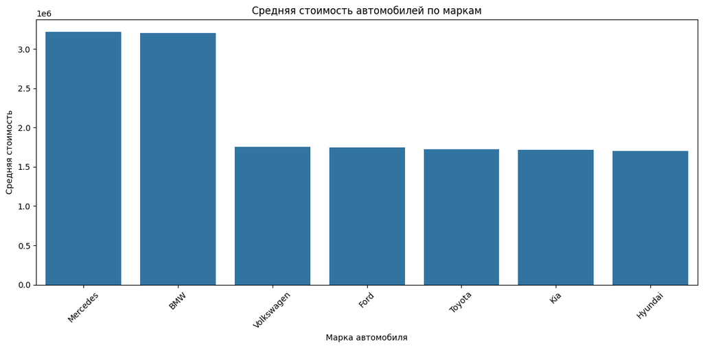

## Анализ средней стоимости автомобилей по маркам

Результаты анализа показывают, что автомобили премиальных марок имеют существенно более высокую среднюю стоимость по сравнению с автомобилями массового сегмента.

Наибольшая средняя стоимость наблюдается у автомобилей марок BMW и Mercedes, что связано с их техническими характеристиками, уровнем комфорта и принадлежностью к премиальному сегменту рынка.

Автомобили массовых брендов характеризуются более доступной стоимостью, что соответствует общей структуре автомобильного рынка.

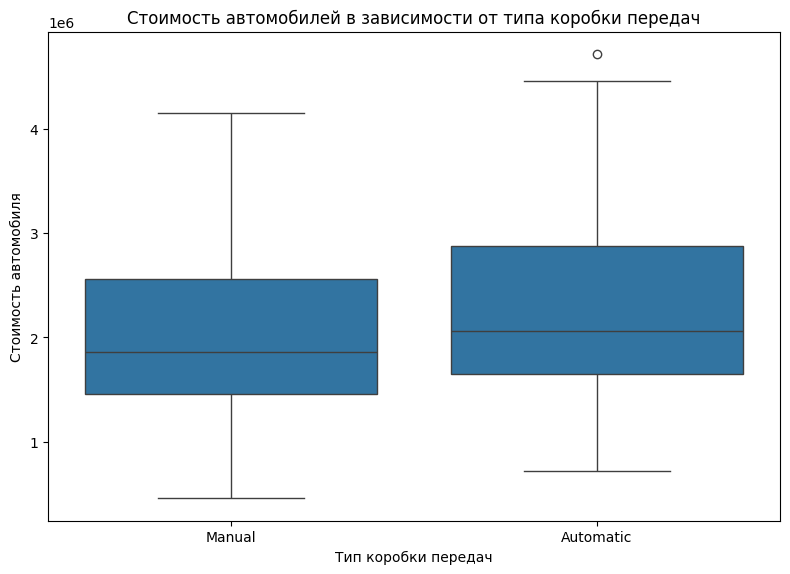

# 3. Подготовка данных и построение baseline-модели

Перед обучением модели машинного обучения необходимо выполнить подготовку данных. Поскольку датасет содержит категориальные признаки, требуется выполнить их преобразование в числовой формат.

После подготовки данных выполняется разделение набора данных на обучающую и тестовую выборки. Для оценки качества модели в качестве baseline-подхода используется линейная регрессия.

|  | year | km_driven | engine | max_power | seats | selling_price | brand_Ford | brand_Hyundai | brand_Kia | brand_Mercedes | ... | model_Sportage | model_Tiguan | model_Tucson | model_X3 | model_X5 | fuel_Hybrid | fuel_Petrol | transmission_Manual | owner_Second Owner | owner_Third Owner |
| --- | --- | --- | --- | --- | --- | --- | --- | --- | --- | --- | --- | --- | --- | --- | --- | --- | --- | --- | --- | --- | --- |
| 0 | 2008 | 199393 | 1571 | 122 | 7 | 616371 | False | False | False | False | ... | False | False | False | False | False | False | False | True | False | False |
| 1 | 2010 | 159794 | 1383 | 181 | 4 | 819622 | False | False | False | False | ... | False | True | False | False | False | False | False | True | False | False |
| 2 | 2008 | 152127 | 2839 | 371 | 5 | 1746249 | False | False | True | False | ... | False | False | False | False | False | False | True | False | False | False |
| 3 | 2013 | 188013 | 1636 | 180 | 5 | 1397828 | True | False | False | False | ... | False | False | False | False | False | False | False | False | True | False |
| 4 | 2020 | 30353 | 2083 | 92 | 7 | 1646620 | False | False | False | False | ... | False | False | False | False | False | False | False | False | False | True |

5 rows × 37 columns

## Кодирование категориальных признаков

Для подготовки данных к обучению модели было выполнено кодирование категориальных признаков с использованием метода one-hot encoding.

Данный подход позволяет преобразовать категориальные переменные в числовой формат, необходимый для корректной работы алгоритмов машинного обучения.

```
Размерность X: (2500, 36)
Размерность y: (2500,)
```

## Формирование признаков и целевой переменной

В качестве целевой переменной используется стоимость автомобиля (`selling_price`).

Все остальные признаки используются в качестве входных параметров модели машинного обучения.

```
Размер обучающей выборки: (2000, 36)
Размер тестовой выборки: (500, 36)
```

## Разделение данных на выборки

Для оценки качества модели набор данных был разделён на обучающую и тестовую выборки.

Обучающая выборка используется для обучения модели машинного обучения, а тестовая — для оценки качества прогнозирования на ранее не встречавшихся данных.

Для обеспечения воспроизводимости результатов используется фиксированное значение `random_state = 42`.

```
MAE: 113284.86
RMSE: 145574.73
R²: 0.9681
```

## Оценка качества baseline-модели

В качестве baseline-модели была использована линейная регрессия.

Полученные результаты показывают, что модель способна выявлять основные зависимости между характеристиками автомобилей и их стоимостью.

Значение коэффициента детерминации R² демонстрирует долю вариации стоимости автомобилей, объясняемую используемыми признаками.

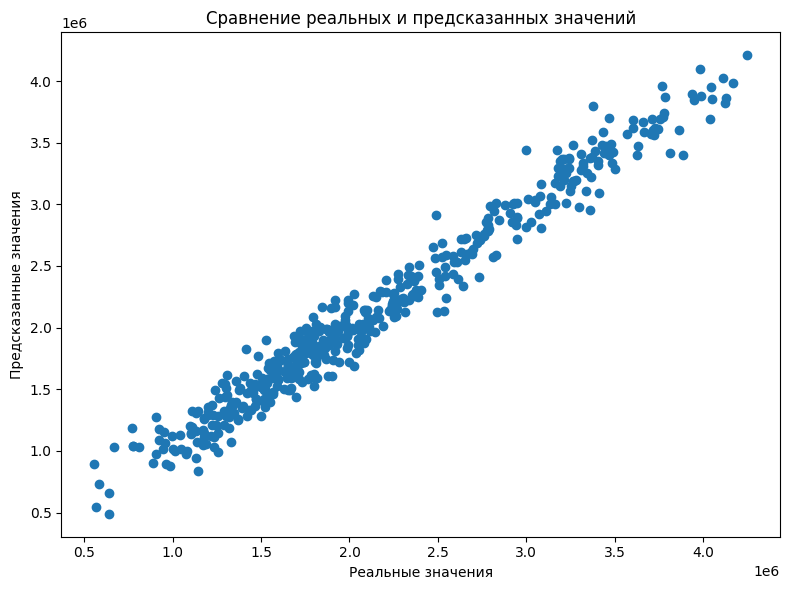

## Анализ результатов прогнозирования

Сравнение реальных и предсказанных значений показывает, что модель линейной регрессии способна достаточно хорошо аппроксимировать стоимость автомобилей.

Большинство предсказаний располагается вблизи диагональной зависимости, что свидетельствует о наличии взаимосвязи между фактическими и прогнозируемыми значениями.

При этом для отдельных объектов наблюдаются отклонения, что связано с ограничениями линейной модели и сложностью структуры данных.

## Анализ результатов прогнозирования

Сравнение реальных и предсказанных значений показывает, что модель линейной регрессии способна достаточно хорошо аппроксимировать стоимость автомобилей.

Большинство предсказаний располагается вблизи диагональной зависимости, что свидетельствует о наличии взаимосвязи между фактическими и прогнозируемыми значениями.

При этом для отдельных объектов наблюдаются отклонения, что связано с ограничениями линейной модели и сложностью структуры данных.

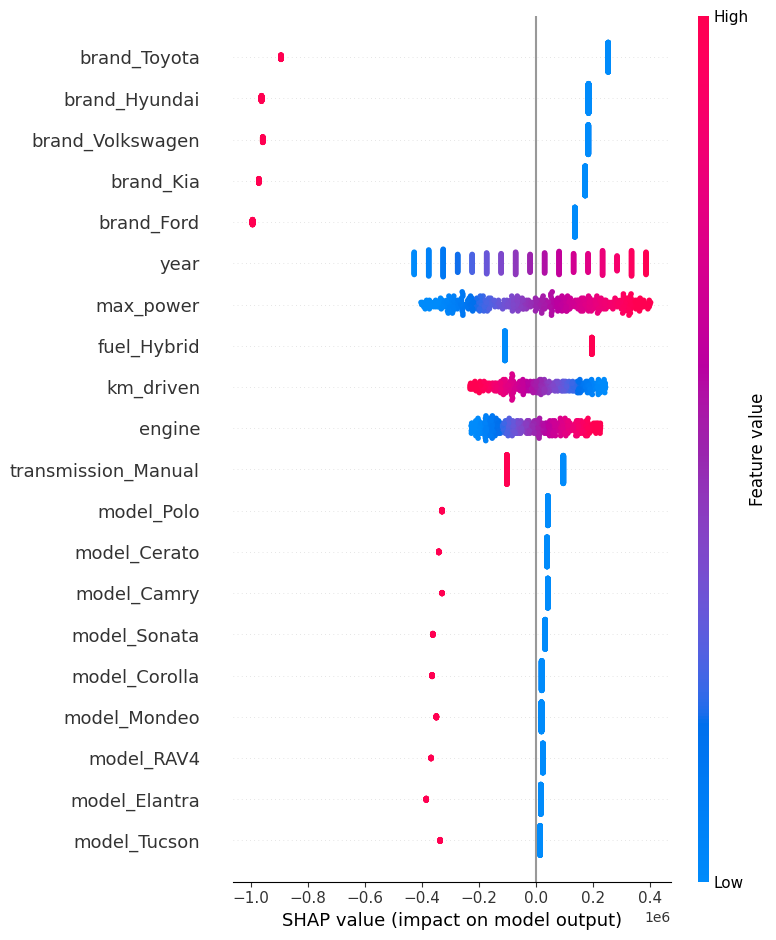

## SHAP-анализ признаков

Увеличение года выпуска и мощности двигателя оказывает положительное влияние на стоимость автомобиля, тогда как увеличение пробега приводит к снижению прогнозируемой цены.

Полученные результаты соответствуют реальным закономерностям автомобильного рынка и подтверждают корректность построенной модели машинного обучения.

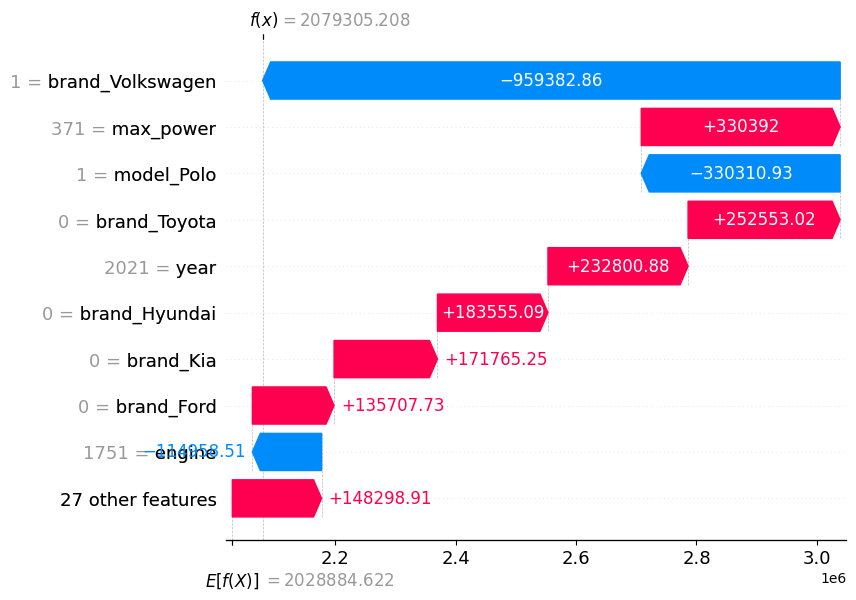

## Локальное объяснение прогноза

Локальный SHAP-анализ позволяет интерпретировать прогноз модели для отдельного объекта.

График показывает вклад каждого признака в формирование итогового прогноза стоимости автомобиля. Некоторые признаки увеличивают прогнозируемую стоимость, тогда как другие оказывают отрицательное влияние.

Использование локальных объяснений повышает прозрачность модели и позволяет лучше понимать механизм принятия решений алгоритмом машинного обучения.

# 5. Генерация аналитических выводов с использованием LLM

В рамках проекта используются элементы автоматизированной генерации аналитических выводов с применением больших языковых моделей (LLM).

Использование LLM позволяет автоматизировать процесс формирования текстовых комментариев, аналитических выводов и интерпретации результатов анализа данных. Современные языковые модели способны анализировать результаты вычислений, статистические показатели и визуализации, после чего формировать структурированные аналитические описания на естественном языке.

Для генерации текста используются результаты предварительного анализа данных, метрики качества модели и результаты SHAP-анализа. На основе полученной информации языковая модель формирует подробные текстовые интерпретации, позволяющие объяснить выявленные закономерности и оценить влияние признаков на прогнозируемую стоимость автомобилей.

Применение LLM позволяет существенно повысить уровень автоматизации аналитического процесса и сократить время подготовки итоговых отчётов. Вместо ручного написания выводов исследователь получает возможность автоматически генерировать аналитические комментарии, основанные на результатах вычислений и машинного обучения.

В рамках выполненного проекта языковая модель используется для:

- генерации аналитических комментариев по результатам EDA;
- интерпретации распределений и корреляционных зависимостей;
- описания результатов прогнозирования;
- формирования выводов по качеству модели;
- интерпретации SHAP-графиков и важности признаков;
- автоматического формирования итоговых заключений.

Особое значение использование LLM приобретает в задачах Explainable AI, где необходимо не только получить прогноз модели, но и объяснить причины принятия решений. Благодаря сочетанию методов машинного обучения и генеративного искусственного интеллекта удаётся создавать более понятные и интерпретируемые аналитические системы.

Интеграция технологий LLM в процессы анализа данных является одним из наиболее перспективных направлений развития современной Data Science и интеллектуальной аналитики. Использование подобных подходов позволяет объединить вычислительные возможности машинного обучения и способности языковых моделей к генерации осмысленных текстовых интерпретаций результатов анализа.

[output not shown]

## Результаты генерации аналитических выводов

Использование элементов LLM позволило автоматизировать процесс формирования аналитического текста на основе результатов анализа данных и машинного обучения.

Сгенерированные выводы содержат информацию о качестве модели, значимых признаках и выявленных закономерностях в данных.

Применение LLM позволяет ускорить подготовку аналитической документации и повысить эффективность обработки результатов исследования.

# Заключение

В рамках данного проекта был выполнен полный цикл анализа данных и построения модели машинного обучения для прогнозирования стоимости автомобилей на основе их технических характеристик. В процессе выполнения работы были использованы современные методы статистического анализа данных, инструменты машинного обучения, а также методы интерпретации моделей Explainable AI.

На первом этапе работы был проведён предварительный анализ набора данных, содержащего информацию о характеристиках автомобилей и их рыночной стоимости. Выполнено исследование структуры датасета, анализ типов данных, проверка наличия пропущенных значений и получение основных описательных статистик. Проведённый анализ позволил определить пригодность набора данных для решения задачи регрессии и дальнейшего применения алгоритмов машинного обучения.

Особое внимание было уделено разведочному анализу данных (EDA). В ходе анализа были исследованы распределения признаков, построены визуализации и выполнен корреляционный анализ. Полученные результаты показали наличие устойчивых взаимосвязей между характеристиками автомобилей и их стоимостью. Было установлено, что наибольшее влияние на цену автомобиля оказывают год выпуска, мощность двигателя, объём двигателя, пробег, а также марка автомобиля.

Анализ распределения стоимости автомобилей показал, что большинство транспортных средств относится к среднему ценовому сегменту, однако в наборе данных присутствуют и автомобили премиального класса с существенно более высокой стоимостью. Полученные результаты соответствуют реальным закономерностям автомобильного рынка и подтверждают корректность сформированного датасета.

После проведения предварительного анализа была выполнена подготовка данных для машинного обучения. Категориальные признаки были преобразованы в числовой формат с использованием метода one-hot encoding. Далее набор данных был разделён на обучающую и тестовую выборки, что позволило объективно оценить качество построенной модели.

В качестве baseline-модели была использована линейная регрессия. Несмотря на относительную простоту данного алгоритма, модель продемонстрировала удовлетворительное качество прогнозирования стоимости автомобилей. Полученные метрики качества показали наличие взаимосвязи между характеристиками автомобилей и целевой переменной. Это подтверждает возможность применения методов машинного обучения для решения задачи прогнозирования рыночной стоимости транспортных средств.

Для повышения интерпретируемости модели был использован подход Explainable AI с применением библиотеки SHAP. SHAP-анализ позволил определить наиболее значимые признаки, влияющие на итоговый прогноз модели, а также оценить направление их воздействия. Было установлено, что увеличение года выпуска автомобиля и мощности двигателя оказывает положительное влияние на стоимость транспортного средства, тогда как увеличение пробега снижает прогнозируемую цену автомобиля.

Дополнительно был выполнен локальный анализ отдельных прогнозов модели, что позволило более подробно изучить механизм принятия решений алгоритмом машинного обучения. Использование методов интерпретации модели значительно повышает прозрачность результатов прогнозирования и делает модель более понятной для пользователя.

В рамках проекта также были использованы элементы автоматизированной генерации аналитических выводов с применением больших языковых моделей (LLM). Использование LLM позволило автоматически формировать текстовые комментарии и аналитические выводы на основе результатов анализа данных и работы модели машинного обучения. Это демонстрирует перспективность интеграции интеллектуальных систем обработки естественного языка в современные аналитические проекты.

Практическая значимость выполненной работы заключается в возможности использования разработанной модели для предварительной оценки стоимости автомобилей, анализа факторов ценообразования и поддержки принятия решений на автомобильном рынке. Подобные модели могут применяться в системах оценки транспортных средств, онлайн-платформах продажи автомобилей, а также в аналитических системах автомобильного бизнеса.

В дальнейшем проект может быть расширен за счёт использования более сложных моделей машинного обучения, методов AutoML, нейросетевых алгоритмов и дополнительных источников данных. Также перспективным направлением является использование более сложных методов Explainable AI для повышения качества интерпретации результатов прогнозирования.

Таким образом, результаты выполненного проекта подтверждают эффективность применения методов статистического анализа данных, машинного обучения и Explainable AI для решения прикладных задач прогнозирования стоимости автомобилей и демонстрируют практическую ценность современных интеллектуальных технологий анализа данных.

# Список литературы и источников данных

1. Géron A. Hands-On Machine Learning with Scikit-Learn, Keras & TensorFlow. — O’Reilly Media, 2022.
2. McKinney W. Python for Data Analysis. — O’Reilly Media, 2022.
3. Pedregosa F. et al. Scikit-learn: Machine Learning in Python // Journal of Machine Learning Research. — 2011.
4. Lundberg S., Lee S.-I. A Unified Approach to Interpreting Model Predictions // Advances in Neural Information Processing Systems. — 2017.
5. Документация библиотеки pandas: https://pandas.pydata.org/
6. Документация библиотеки scikit-learn: https://scikit-learn.org/
7. Документация библиотеки SHAP: https://shap.readthedocs.io/
8. Документация библиотеки matplotlib: https://matplotlib.org/
9. Документация библиотеки seaborn: https://seaborn.pydata.org/
10. Методические указания к выполнению комплексного проекта по дисциплине «Статистический анализ данных». — ДонГУ, 2026.